# HW_5

Sindupa De Silva

3/29/2021

Included in this homework is an example occupancy modeling dataset obtained from camera trap data across 6 mid-Atlantic states:

**Bobcat.csv**: detection / non-detection of bobcat at each camera. Each row is a camera, and each column is a replicate survey (1 day).

**p covariates.csv**: number of people (divided by 100) photographed. Each row is a camera, and each column is a replicate survey (1 day). This is a detection covariate.

**psi covariates.csv**: the single covariate represents the proportion of area within 5km recently disturbed (e.g., logging, housing development). Treat this as a site-level covariate.

1. Load data and place into an unmarkedFrameOccu object

```r
library(unmarked)
# Import data
Bobcats <- read.csv('Bobcat.csv') # detection/ non-detection
People <- read.csv('p covariates.csv') # detection covariate
Disturbance <- read.csv('psi covariates.csv') # site-level covariate

# check data type
class(Bobcats)
```

```
## [1] "data.frame"
```

```r
class(People)
```

```
## [1] "data.frame"
```

```r
class(Disturbance)
```

```
## [1] "data.frame"
```

```r
# Create a list of site-level covariates
People_2 <- list(Cameras = People)

# check data type again
class(People_2)
```

```
## [1] "list"
```

```r
# Place the data into an unmarkedFrameOccu object
Occu_data <- unmarkedFrameOccu(y = as.matrix(Bobcats), # detection / non-detection
                                 siteCovs = Disturbance, # site-level covariate
                                 obsCovs = People_2) # detection covariate
```

2. Fit an occupancy model that assumes conditional detection probability is a function of the number of people photographed at a site, and occupancy probability is a function of disturbance within 5km.

```r
# Occupancy model for conditional detection probability
Fit_occu <- occu(~ Cameras ~ Dist_5km, data = Occu_data)
summary(Fit_occu)
```

```
##
## Call:
## occu(formula = ~Cameras ~ Dist_5km, data = Occu_data)
##
## Occupancy (logit-scale):
##             Estimate    SE      z  P(>|z|)
## (Intercept)    -1.05 0.101 -10.39 2.63e-25
## Dist_5km      -23.64 4.773  -4.95 7.28e-07
##
## Detection (logit-scale):
##             Estimate     SE       z P(>|z|)
## (Intercept)  -3.0133 0.0741 -40.646   0.000
## Cameras      -0.0609 0.3779  -0.161   0.872
##
## AIC: 4462.98
## Number of sites: 1951
## optim convergence code: 0
## optim iterations: 39
## Bootstrap iterations: 0
```

3. Interpret the effect of the number of people photographed at each site on conditional detection probability of bobcat. Verify your interpretation in R.

```r
# Extract the coefficients
Betas <- coef(Fit_occu)

# Log odds detection probability
Betas[4]
```

```
##  p(Cameras)
## -0.06088908
```

```r
# Effect on detection probability
plogis(Betas[4])
```

```
## p(Cameras)
##  0.4847824
```

```r
# Effect of the number of people photographed at each site on the detection probability of Bobcats

Detect_1 <- Betas[3] + Betas[4]
Detect_2 <- Betas[3] + Betas[4] * 0

Detect_1 - Detect_2
```

```
##      p(Int)
## -0.06088908
```

For every 1-unit change in the effect of “number of people photographed” at each site, there is a -0.06 effect on the log odds of detecting a Bobcat.

4. Re-create the Wald test for the effect of disturbance within 5km. What is the null hypothesis? Do you reject or fail to reject this null hypothesis?

```r
# From Fit_occu summary
SE <- 4.773

# Wald test
Wald <- Betas[2] / SE
Wald
```

```
## psi(Dist_5km)
##     -4.953664
```

```r
# p-value
2 * pnorm(-1 * abs(Wald))
```

```
## psi(Dist_5km)
##  7.282885e-07
```

Our null hypothesis is that there is no effect of disturbance within 5 km on the occupancy of Bobcats, but with a p-value < 0.05, we reject our null hypothesis.

5. Predict and plot the effect of disturbance within 5km on bobcat occupancy probability. Do this over the range of observed disturbance within 5km.

```r
# New data frame of observed range of disturbance within 5 km
new_psi <- data.frame(Dist_5km = seq(from = min(Disturbance$Dist_5km),
           to = max(Disturbance$Dist_5km), length.out = 1951))

# Predicting the effect of disturbance on Bobcat occupancy
predict_occupancy <- predict(object = Fit_occu, newdata = new_psi, type = 'state')

# Checking the predictions
plogis(coef(Fit_occu[1]) + coef(Fit_occu[2]) * min(Disturbance$Dist_5km))
```

```
##      psi(Int) psi(Dist_5km)
##  2.600236e-01  5.390277e-11
```

```r
# Compared to values from above
predict_occupancy[1,1]
```

```
## [1] 0.2600236
```

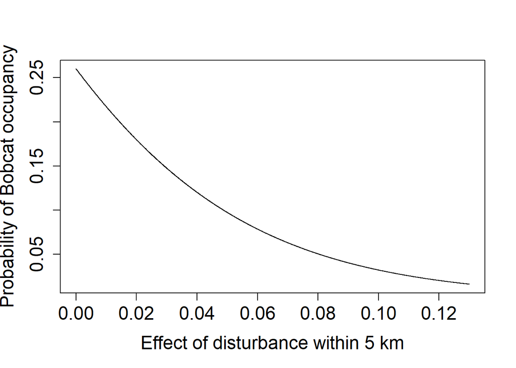

```r
# Plot the results
plot(x = new_psi$Dist_5km, y = predict_occupancy$Predicted, ylab = 'Probability of Bobcat occupancy',  xlab = 'Effect of disturbance within 5 km', cex.axis = 1.5, cex.lab = 1.5, type = 'l')
```